# Algorithm Class 7 - Practice 4

Linked List and Java List

June/2/2019

# 1 Implementation of Linked List

```java
class ListNode {
  public int value; // any type
  public ListNode next; // this ListNode is a reference
  // public ListNode prev;
  public ListNode(int value) {
    this.value = value;
    this.next = null;
  }
}

ListNode head = new ListNode(3);
head.next = new ListNode(4);
```

# 2 Difference between Array and List

To represent sequence of elements: array/list

- array: {1, 2, 3} - the elements are stored in consecutive memory.

```
[ 1 | 2 | 3 ]
```

- list: {1, 2, 3} - the elements are not stored in consecutive space, but are connected by the pointer/references.

```
[ 1 | next ] head
       /
      /
     /
    /
   /
  V
[ 2 | next ]
       /
      /
     /
    /
   /
  V
[ 3 | next ]
```

For list, we need to always know where the “HEAD” is, so that we can traverse/find any elements in the list by iterating the “next” reference.

# 3 Array v.s. Linked List Comparison

- Memory Layout
  - Array: consecutive allocated memory space, no overhead
  - Linked List: non-consecutive, overhead of multiple objects with the “next” reference
- (Random) Access Time? - get the i-th element
  - Array: O($1$), calculating the offset is O($1$), e.g. `int value = array[5];`
  - Linked List: O($n$) worst case, we can only traverse from the “HEAD”
- Search Time (Non-sorted)?
  - Array: O($n$)
  - Linked List: ($n$)
- Search Time (Sorted)?
  - Array: O($\log(n)$) - binary search
  - Linked List: O($n$)
  - **Reason:** random access time is different for array and list

# 4 Objects, Reference, null in Linked List Operations

```java
class ListNode {
  public int value;
  public ListNode next;
  // public ListNode prev; -> Doubly Linked List, very powerful, covered later
  public ListNode(int value) {
    this.value = value;
    this.next = null;
  }
}
```

Let’s review this block of codes first:

```java
ListNode current = null;
ListNode next = null;
current = new ListNode(0);
next = new ListNode(1);
ListNode temp = current;  // temp
current.next = next;  // 這步寫在了heap中, 可持續
current = current.next;
```

What is current, temp, next at this point finishing all the lines above?

- current.value: 1
- next.value: 1
- temp.value: 0

**Breakdown:**

null: the reference is not pointed to any Object on the Heap. (null is a special value for reference)

- Step 1
  1. Initialize to null, not pointing to any concrete object in the heap.

```java
ListNode current = null;
ListNode next = null;
```

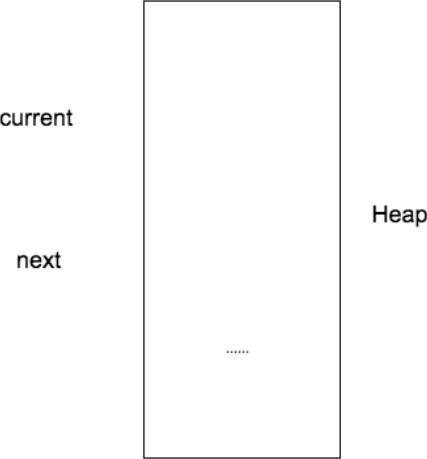

- Step 2
  1. Allocate space on heap and create a new ListNode object with {value = 0, next = null}
  2. Return the object’s memory address as the value of reference.

```java
current = new ListNode(0);
```

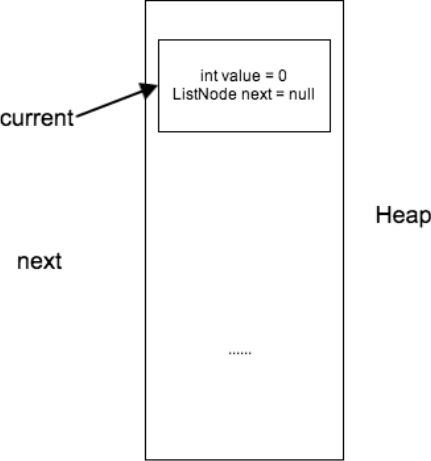

- Step 3

```java
next = new ListNode(1);
```

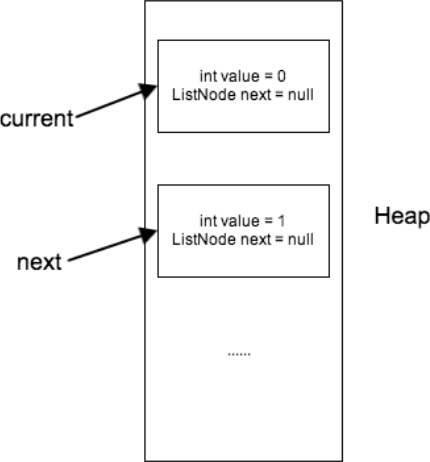

- Step 4
  1. temp will be assigned the same value as current, which means temp is pointed to the same ListNode object where current is pointed to.

```java
ListNode temp = current;
```

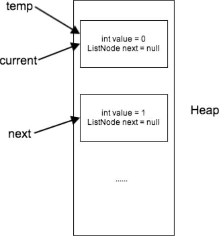

- Step 5
  1. Dereferencing current to find the actual ListNode object, change the next field.

```java
current.next = next;
```

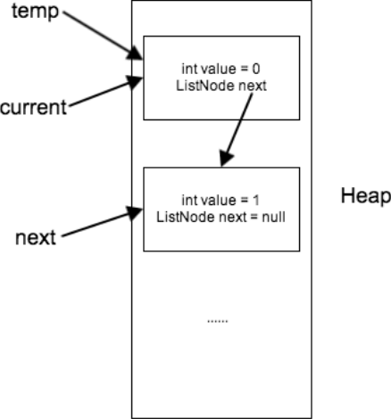

- Step 6

```java
current = current.next;
```

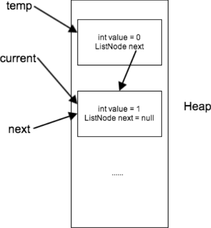

What about we adding these two lines after? What would be the result?

- Line 1

```java
temp.next = temp.next.next; // temp.next = null; 不會有NPE
```

- Line 2 (NPE!!!)

```java
current.next = current.next.next; // NullPointerException!
// (current.next).next <-> null.next
```

# 5 Linked List Operations

## 5.1 `length()`

1 -> 2 -> 3 -> null

```
// written by student
public int length(ListNode head) {
  int counter = 0;
  ListNode temp = head;
  while(temp != null) {
    temp = temp.next;
    counter++;
  }
  return counter;
}
```

Or, we can just use head without temp. Because in Java, it’s pass by value, and the head is only a copy of the reference.

```java
int length(ListNode head) {
  int length = 0;
  while (head != null) {
    length++;
    head = head.next;
  }
  return length;
}
```

## 5.2 `get()`

1 -> 2 -> 3 -> null

index = 0 -> return 1

index = 4 -> return null

```
// written by student
public ListNode get(ListNode head, int index) {
  ListNode current = head;
  int counter = index;
  while(current != null && counter >= 1) {
    current = current.next;
    counter--;
  }
  // DeMorgain's Law: curr == null || counter < 1 (counter == 0)
  // post-processing
  return current == null ? null : current;
}
```

```java
ListNode get(ListNode head, int index) {
  while (index > 0 && head != null) {
    head = head.next;
    index--;
  }
  return head;
}
```

## 5.3 `appendHead()`

```java
ListNode appendHead(ListNode head, int value) {
  ListNode newHead = new ListNode(value);
  newHead.next = head;
  return newHead;
}
```

## 5.4 `appendTail()`

```java
ListNode appendTail(ListNode head, int value) {
  // 1. head == null
  if (head == null) {
    return new ListNode(value);
  }
  // 2. head != null, find the last node in the list
  ListNode prev = head;
  while (prev.next != null) {
    prev = prev.next;
  }
  // exit the while loop when prev.next == null
  prev.next = new ListNode(value);
  return head;
}
```

head could be changed - we need to return the new head if changed

usually need to consider:

- head == null: after the last node
- head.next == null: on the last node

while loop: we need to understand what is the terminate condition

## 5.5 `remove()`

Assuming no duplicate values, 1 -> 2 -> 3 -> null, remove(2), result 1 -> 3 -> null

```java
ListNode remove(ListNode head, int value) {
  // 1. head == null
  if (head == null) {
    return null;
  }
  else if (head.value == value) { // 2. remove head
    return head.next;
  }
  // 3.
  ListNode current = head;
  while(current.next != null && current.next.value != value) {
    current = current.next;
  }
  // out of the while loop, current.next == null || current.next.value == value
  if (current.next != null) {
    current.next = current.next.next;
  }
  return head;
}
```

# 6 LinkedList in Java

Backend by a doubly linked list, wrap the size, head and tail information.

```java
class ListNode<E> {
  E e;
  private ListNode<E> prev;
  private ListNode<E> next;
}

class LinkedList<E> {
  private ListNode<E> head;
  private ListNode<E> tail;
  private int size;

  public E get(int index) {
    // traverse from the head and find the node at index
  }

  // ... other operations provided...
}
```

- `get(int index)`
  - from the head/tail, traverse the list to get the element at index
- `set(int index, E e)`
  - from the head/tail, traverse the list to get the element at index, and change it
- `add(int index, E e)`, `add(E e)`
  - at tail: append new node after tail and update tail to the new added node
  - at head: insert in front of the head, and update head to the new added node
  - at middle
- `remove(int index)`
  - at head: update the head to head.next
  - at tail: update the tail to tail.prev
  - at middle: from head/tail, traverse the list to get the element at index, and remove it.
- `size()`
  - Time: O($1$), eager computation
- `isEmpty()`
  - `return size == 0;`, 直接返回判斷的布爾值

```java
List<Integer> list = new LinkedList<Integer>();

System.out.println(list.size());  // 0

list.add(1);  // add at end, {1}
System.out.println(list.size());  // 1

list.add(0, 2); // add at head, {2, 1}
System.out.println(list.size());  // 2

list.add(1, 3); // add at middle, {2, 3, 1}
System.out.println(list.get(1));  // 3
list.remove(1); // {2, 1}
System.out.println(list.set(0, 4)); // {4, 1}
System.out.println(list); // {4, 1}
```

## 6.1 `E` (Element)

1. 裝什麽類型就寫什麽類型: `LinkedList<Student> l = new LinkedList<>();`
2. Cannot be a primitive type (int: Integer, char: Character, boolean: Boolean, wrapper class)
3. `LinkedList<Student> l = new LinkedList<>();`, `<>`: diamond operator, the same as left hand side. Supported by Java 7.

# 7 List Interface in Java

- An ordered collection (sometimes called a sequence).
- Lists can contain duplicate elements.

The user of a List generally has precise control over where in the list each element is inserted and can access elements by their index.

Provided functionalities (interfaces):

- Random Access:
  - `set(int index, E e)`
  - `get(int index)`
  - `add(int index, E e)`, `add(E e)`
  - `remove(int index)`
- Search
- Iterator
- Range-view
- Other useful methods:
  - `isEmpty()`
  - `size()`

Most popular implementation class: LinkedList, ArrayList.

# 8 Abstract Class, Interface

## 8.1 Semantics (語義) v.s. Implementations (實現)

Separate semantic and implementation: language specs define semantics, language implementations (such as JVM) defines the actual behavior of a program.

E.g., in real life: 菜譜 v.s. 做飯, 攻略 v.s. 打游戲

Semantically:

1. `int i = 0;`
2. `i++;`, now i = 1

In one implementation:

1. Set i to be 0
2. Read i, i = 0
3. Perform 0 + 1 = 1
4. Write new value 1 back to i’s memory location

The actual execution sequence varies (different JVMs, different architectures, etc.), but the “meaning” of the program remains unchanged.

## 8.2 Abstract Class and Interfaces

Both can have methods declared without implementation (abstract methods). “Protocol”

```
interface 貓 {
  public void 抓老鼠()
}
public class 黑貓 implements 貓 {
  public void 抓老鼠() {
    // 黑貓抓老鼠的姿勢
  }
}
public class 白貓 implements 貓 {
  public void 抓老鼠() {
    // 白貓抓老鼠的姿勢
  }
}
```

```java
interface Dictionary {
  // index out of bound, it will return null
  public Integer get(int index);
}

// Dictionary myDict = new Dictionary(); Wrong! Interface cannot be used to instantiate an object

class DictionaryImpl implements Dictionary {
  @Override
  public Integer get(int index) {
    // ...
  }
}

Dictionary myDict = new DictionaryImpl();
myDict.get(100);
```

Abstract class/Interface: you **cannot** instantiate an object by abstract class or interface.

```java
public int search(A a, int target) {
  return a.print();
}

interface A {
  public void print();
}

class B implements A {
  @Override
  public void print() {
    System.out.println("B");
  }
}
```

Good practice: Declare into a general type, initialize into a concrete type (Interfaces are also types):

```java
List<Node> myList = new LinkedList<Node>();
myList.get(5);  // fine
myList.set(5, 7); // fine
myList.poll();  // not fine, because the method poll() is not belong to List, but other data structures (i.e. Queue)
```

1. Preserve the general semantic of a List
   - Can only use methods in a List interface
   - Not to make any assumptions on implementation
   - Make sure interchangeable in future
2. Provide concrete implementation by using LinkedList
   - Choose the best implementation for the current use case

“API”: Application Programming Interface

“REST API”

# 9 Extra Reading

https://docs.oracle.com/javase/tutorial/java/IandI/abstract.html

| **Abstract Class** | **Interface** |
| --- | --- |
| 1. Abstract class can **have abstract and non-abstract** methods. | Interface can have **only abstract** methods. |
| 2. Abstract class **doesn’t support multiple inheritance**. | Interface **supports multiple inheritance**. |
| 3. Abstract class **can have final, non-final, static and non-static variables**. | Interface has **only static and final variables**. |
| 4. Abstract class **can have static methods, main method and constructor**. | Interface **can’t have static methods, main method or constructor**. |
| 5. Abstract class **can provide the implementation of interface**. | Interface **can’t provide the implementation of abstract class**. |
| 6. The **abstract keyword** is used to declare abstract class. | The **interface keyword** is used to declare interface. |

vtable, polymorphism